# Data Analysis for Study 1

# Study 1 Introduction

This Markdown documents the process to analyze the data for Study 1.

Data was collected on October 20th, 2017 by using Amazon’s Mechanical Turk for ditribution and Qualtrics as a survey platform.

This HTML was last knitted on: 2019-09-08 16:36:35

## Set Up

### Packages and Libraries

You must run this section before you can run any other chunks.

### Data Import

You must run this section before you can run any other chunks.

## Methods

### Participants

| dem_gender | n |
| --- | --- |
| female | 9 |
| male | 14 |
| non-binary | 1 |

| mean_age | sd_age | median_age | min_age | max_age | range_age |
| --- | --- | --- | --- | --- | --- |
| 31.91667 | 9.481867 | 28.5 | 19 | 59 | 40 |

| dem_ed | n | percentage |
| --- | --- | --- |
| 2 | 4 | 16.666667 |
| 3 | 5 | 20.833333 |
| 5 | 3 | 12.500000 |
| 6 | 10 | 41.666667 |
| 7 | 1 | 4.166667 |
| 8 | 1 | 4.166667 |

### Power

Our post-hoc power analysis showed that this sample size is powered to detect a two-tailed effect size of 0.69 with an α of 0.05 and 0.9 power in a within-subjects design (Faul, Erdfelder, Lang, & Buchner, 2007). Procedures in this and all following studies were approved by the Duke University IRB.

## Results

### The effect of axis truncation on qualitative judgment: truncation effect

| condition | n | mean | sd | median | min | max | range |
| --- | --- | --- | --- | --- | --- | --- | --- |
| control | 24 | 3.695833 | 0.4130788 | 3.650 | 3.00 | 5 | 2.00 |
| truncated | 24 | 4.775000 | 0.6277981 | 4.825 | 3.55 | 6 | 2.45 |

First, we examined how the control versus truncated bar graph manipulation affected participant ratings of how different two quantities are (i.e. graph ratings). As hypothesized, we found that people rated the differences depicted by truncated graphs as larger than those depicted by control graphs: M<sub>control</sub> = 3.7 (SD<sub>control</sub> = 0.41); M<sub>truncated</sub> = 4.78 (SD<sub>truncated</sub> = 0.63).

```
##
##  Paired t-test
##
## data:  subject_mean_rating by condition
## t = -14.253, df = 23, p-value = 0.000000000000664
## alternative hypothesis: true difference in means is not equal to 0
## 95 percent confidence interval:
##  -1.2357975 -0.9225358
## sample estimates:
## mean of the differences
##               -1.079167
```

```
##
## Cohen's d
##
## d estimate: -1.263085 (large)
## 95 percent confidence interval:
##      lower      upper
## -1.8994651 -0.6267043
```

A paired t-test revealed that this difference was statistically significant with a large effect size, t(23) = 14.25, p < 0.000, M<sub>difference</sub> = 1.08, d = 1.26. *Figure 3A* illustrates these results, depicting means with 95% confidence intervals, individual participants, and distributions for both conditions

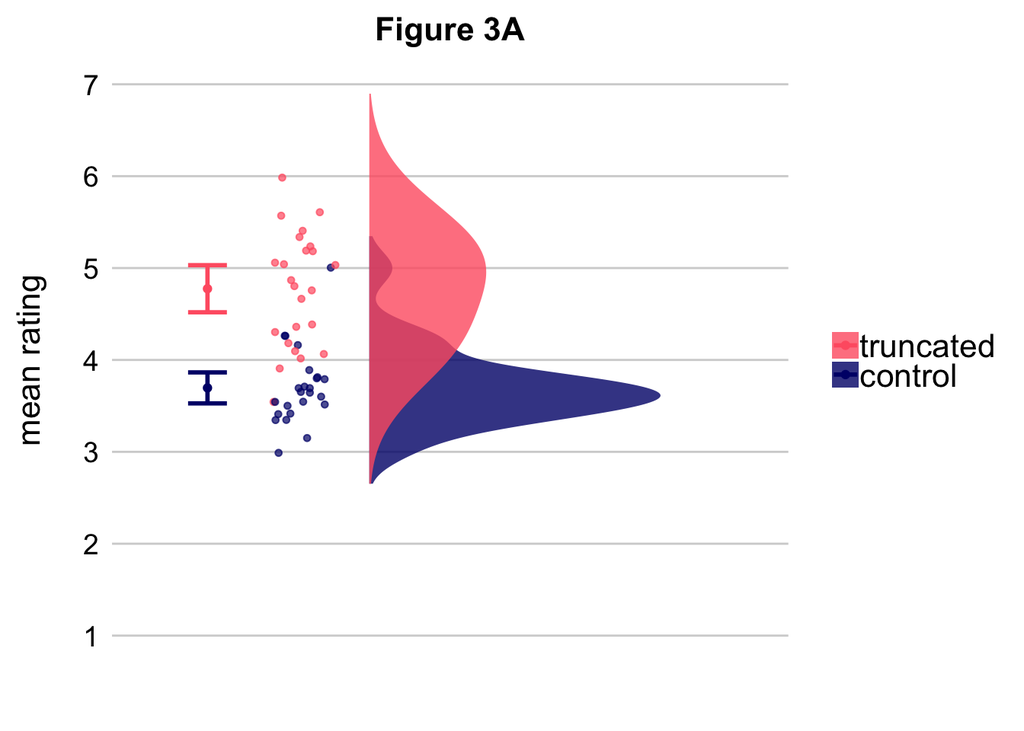

| n | mean_difference | sd | median | min | max | range |
| --- | --- | --- | --- | --- | --- | --- |
| 24 | 1.079167 | 0.370932 | 1.15 | 0.4 | 1.75 | 1.35 |

Thus, when presented with truncated y-axes rather than y-axes that begin at 0, participants judge differences to be larger. This effect was consistent across participants: all 24 participants rated differences depicted by truncated graphs as larger than those depicted by control graphs, with the size of that difference ranging from 0.4 to 1.75. We call this effect of axis truncation on qualitative judgments of differences the *truncation effect*.

### Graph literacy

```
## Some items ( 7 10 ) were negatively correlated with the total scale and
## probably should be reversed.
## To do this, run the function again with the 'check.keys=TRUE' option
```

| n | mean | sd | median | min | max | range | alpha |
| --- | --- | --- | --- | --- | --- | --- | --- |
| 24 | 44.08333 | 5.307228 | 43.5 | 35 | 55 | 20 | 0.72 |

Next, we investigated the role of graph literacy in predicting people’s graph ratings. Graph literacy scores ranged from 35 to 55 in Study 1 (M = 44.08, SD = 5.31).

```
##
## Call:
## lm(formula = difference ~ graphliteracy_sum_rating, data = models_difference_df)
##
## Residuals:
##      Min       1Q   Median       3Q      Max
## -0.69923 -0.22896  0.06344  0.24748  0.67104
##
## Coefficients:
##                          Estimate Std. Error t value Pr(>|t|)
## (Intercept)              0.967456   0.660997   1.464    0.157
## graphliteracy_sum_rating 0.002534   0.014891   0.170    0.866
##
## Residual standard error: 0.379 on 22 degrees of freedom
## Multiple R-squared:  0.001315,   Adjusted R-squared:  -0.04408
## F-statistic: 0.02896 on 1 and 22 DF,  p-value: 0.8664
```

A linear model predicting the difference between control and truncated graphs for each participant was not predictive: F(1, 22) = 0.03, p = 0.87, adjusted R2 = -0.04.

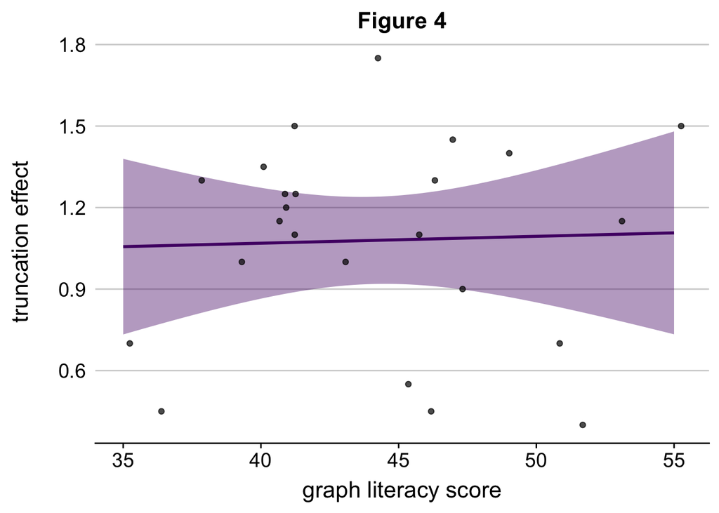

## Supplemental Information

### Methods (Supplemental Information)

#### Participants (Supplemental Information)

| dem_language | n |
| --- | --- |
| English | 24 |

24 participants reported English as their first language.

| mean_duration | sd_duration | median_duration | min_duration | max_duration | range_duration |
| --- | --- | --- | --- | --- | --- |
| 20.97292 | 17.62977 | 15.99167 | 6.5 | 85.81667 | 79.31667 |

The experiment took participants an average of M<sub>duration</sub> = 20.97 minutes, (SD<sub>duration</sub> = 17.63 minutes). Participants were paid US $3.50 for participating.

### Results (Supplemental Information)

#### Education (Supplemental Information)

Education Anova

```
##             Df Sum Sq Mean Sq F value Pr(>F)
## dem_ed       5  1.270  0.2539   2.412 0.0768 .
## Residuals   18  1.895  0.1053
## ---
## Signif. codes:  0 '***' 0.001 '**' 0.01 '*' 0.05 '.' 0.1 ' ' 1
```

Education and graph literacy

```
##
## Call:
## lm(formula = graphliteracy_sum_rating ~ dem_ed, data = models_difference_df)
##
## Residuals:
##      Min       1Q   Median       3Q      Max
## -10.1749  -4.1749  -0.1635   2.8403   8.8403
##
## Coefficients:
##             Estimate Std. Error t value           Pr(>|t|)
## (Intercept)   47.190      2.663  17.722 0.0000000000000164 ***
## dem_ed        -1.008      0.791  -1.274              0.216
## ---
## Signif. codes:  0 '***' 0.001 '**' 0.01 '*' 0.05 '.' 0.1 ' ' 1
##
## Residual standard error: 5.237 on 22 degrees of freedom
## Multiple R-squared:  0.06869,    Adjusted R-squared:  0.02636
## F-statistic: 1.623 on 1 and 22 DF,  p-value: 0.216
```

#### Age (Supplemental Information)

Age Linear Regression

```
##
## Call:
## lm(formula = difference ~ dem_age, data = models_difference_df)
##
## Residuals:
##     Min      1Q  Median      3Q     Max
## -0.7121 -0.2223  0.1527  0.2100  0.4648
##
## Coefficients:
##             Estimate Std. Error t value Pr(>|t|)
## (Intercept) 0.751820   0.267531   2.810   0.0102 *
## dem_age     0.010256   0.008049   1.274   0.2159
## ---
## Signif. codes:  0 '***' 0.001 '**' 0.01 '*' 0.05 '.' 0.1 ' ' 1
##
## Residual standard error: 0.366 on 22 degrees of freedom
## Multiple R-squared:  0.06874,    Adjusted R-squared:  0.02641
## F-statistic: 1.624 on 1 and 22 DF,  p-value: 0.2159
```

Figure depicts this null relationship (age)

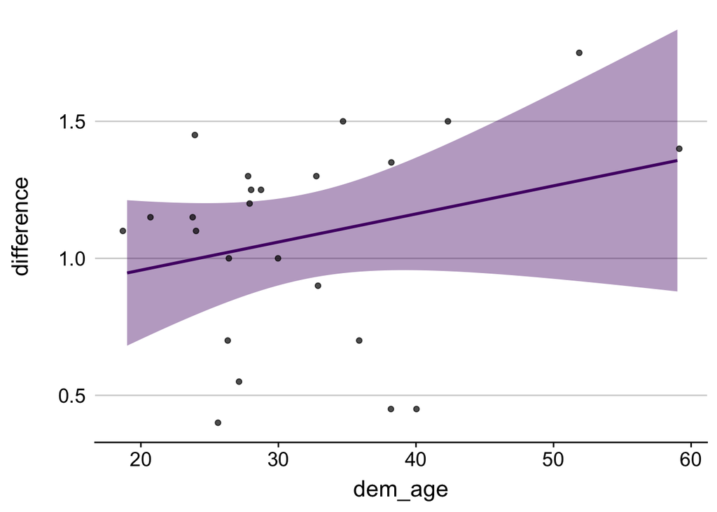

#### Item Analysis (Supplemental Information)

Here we summarise the data for each item. This is helpful to identify if the effect is driven by a few graphs or if it is seen across all graphs in the materials.

| question | control | truncated | diff |
| --- | --- | --- | --- |
| 1 | 3.307692 | 4.272727 | 0.96503497 |
| 2 | 4.090909 | 5.384615 | 1.29370629 |
| 3 | 2.076923 | 3.363636 | 1.28671329 |
| 4 | 4.181818 | 5.692308 | 1.51048951 |
| 5 | 4.230769 | 6.090909 | 1.86013986 |
| 6 | 3.454545 | 4.076923 | 0.62237762 |
| 7 | 3.846154 | 6.181818 | 2.33566434 |
| 8 | 2.545455 | 4.538462 | 1.99300699 |
| 9 | 3.538462 | 4.727273 | 1.18881119 |
| 10 | 1.909091 | 3.153846 | 1.24475524 |

[output cut: 30 more lines]

| n | mean | sd | median | min | max | range |
| --- | --- | --- | --- | --- | --- | --- |
| 40 | 1.084266 | 0.5860298 | 1.143357 | 0.02097902 | 2.335664 | 2.314685 |

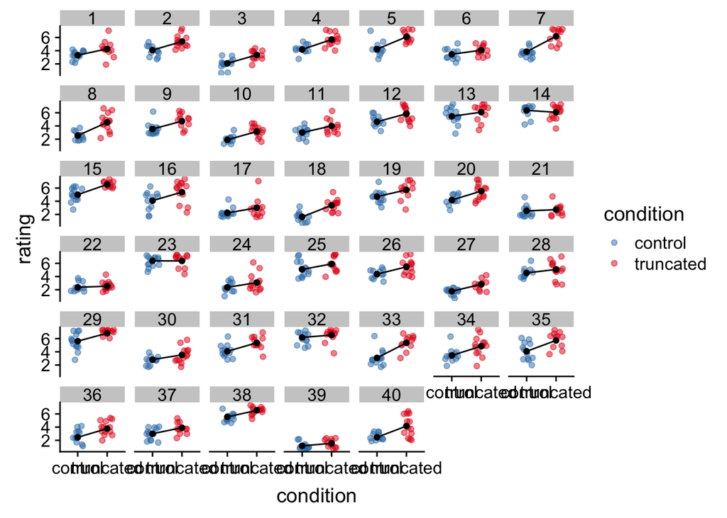

| question | control | truncated | diff |
| --- | --- | --- | --- |
| 14 | 6.363636 | 6.076923 | -0.28671329 |
| 23 | 6.384615 | 6.363636 | -0.02097902 |

The truncation effect was observed for all graphs except graph 14, 23. On average, the 7-point ratings were 1.08 (SD = 0.59) higher when graphs were seen in the truncated condition than when they were seen in the control condition. The maximum average absolute difference between the truncated and control conditions was for graph 7 M = 2.34. The minimum average absolute difference was for graph 23 where M = 0.02.

#### Timing (Supplemental Information)

Timing information is in seconds.

You can choose to trim or not timing data. By default any timing that is 2 standard deviations away from the mean (for each participant for each condition) is trimmed.

For this report, any timing that is 2 standard deviations away from the mean (for each participant for each condition) WAS trimmed. If you want to see results when participants who got the exercise wrong are excluded/included, you can go to the section called Exclusions (at the top of this file) and change **Trimming <- FALSE**

| condition | n | mean | sd | median | min | max | range |
| --- | --- | --- | --- | --- | --- | --- | --- |
| control | 24 | 11.26476 | 9.290803 | 8.784842 | 3.533579 | 43.46517 | 39.93159 |
| truncated | 24 | 11.31152 | 6.828720 | 10.522091 | 4.157944 | 29.43783 | 25.27989 |

Item Analysis for Timing

| condition | n | mean | sd | median | min | max | range |
| --- | --- | --- | --- | --- | --- | --- | --- |
| control | 40 | 11.25430 | 3.935369 | 10.49265 | 7.038692 | 28.04350 | 21.00481 |
| truncated | 40 | 11.18409 | 4.501462 | 10.21028 | 6.764300 | 33.14264 | 26.37834 |

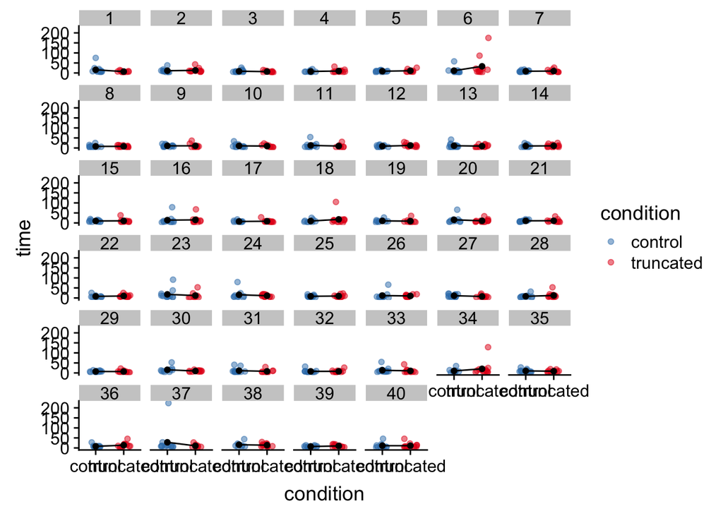